# Vivian van Oosten : AM11 Individual Assignment Part 3: SVM and ANN

# Introduction

We have a dataset of movies, including their genres, ratings and tags provided by specific users.

Our goal in this document is to correctly predict the rating of movies. We start off by predicting whether a movie is good or bad, depending on your definition of good and bad. Then, we try to predict the exact average rating that a movie would have.

Both instances can be used by individuals and companies for various purposes. For the good/bad movie prediction, we are optimizing from a consumer perspective. The goal is to find a movie to watch that night for which we don’t have the ratings. We train the model to predict whether a movie is good based on the genres and the PCAs from the text mining of the tags. For the exact rating, we optimize for a company that is trying to assess whether or not to add a movie to their streaming service. For example an airline with a limited amount of movies on its platform.

# Creating dataset

Before we can start any of the modelling, we will create the dataset.

```r
movies <- fread('ml-25m/movies.csv')

features_fromPart2 <- readRDS('features_fromPart2.rds', refhook = NULL)

ratings <- fread('ml-25m/ratings.csv')
```

Since our PCA features aren’t defined for all movies, we only select those movies that have values for PCA.

```r
movies <- movies %>%
  filter(movieId %in% features_fromPart2$movieId)

ratings <- ratings %>%
  filter(movieId %in% movies$movieId)
```

To clean our dataset, we remove any duplicates we might have.

```r
repeatMovies <- names(which(table(movies$title) > 1))
if (length(repeatMovies)  > 0 ) {
removeRows <- integer()
for(i in repeatMovies){
  repeatMovieLoc <- which(movies$title == i)
  tempGenre <- paste(movies$genres[repeatMovieLoc], collapse="|")
  tempGenre <- paste(unique(unlist(strsplit(tempGenre, split = "\\|")[[1]])), collapse = "|")
  movies$genres[repeatMovieLoc[1]] <- tempGenre

  ##### REMOVE REPEATS IN RATING DATA ####
  repeatMovieIdLoc <- which(ratings$movieId %in% movies$movieId[repeatMovieLoc[-1]])
  ratings$movieId[repeatMovieIdLoc] <- movies$movieId[repeatMovieLoc[1]]
  removeRows <- c(removeRows, repeatMovieLoc[-1])
}
movies$movieId[removeRows]
movies <- movies[-removeRows,]
rm(i, removeRows, repeatMovieIdLoc, repeatMovieLoc, repeatMovies, tempGenre)}
```

Next, we need to remove any user that has rated a single movie twice. We only keep the highest rating if they have rated a single movie twice.

```r
duplicate_ratings_keep <- ratings %>%
  get_dupes(userId, movieId) %>%
  group_by(userId, movieId) %>%
  summarise(rating = max(rating))
```

```
## No duplicate combinations found of: userId, movieId
```

```r
ratings <- ratings %>%
  # completely removing all duplicates
  group_by(userId, movieId) %>%
  filter(n()==1) %>%
  # adding the desired duplicates back in
  left_join(duplicate_ratings_keep)
```

Our dataset needs to end up with dummy variables for all the genres we have and the average rating for each movie. These variables are created below.

```r
# getting the average rating per movie
av_rating <- ratings %>%
  group_by(movieId) %>%
  summarise(av_rating = mean(rating))

rm(ratings)

# generating the dummy variables for the genres
genres_df <- movies %>%
  #splitting the genre string into a list of genres
  mutate(genres = strsplit(genres, split = "\\|")) %>%
  # creating a long dataframe with each row being 1 genre for each movie
  unnest(genres) %>%

  # preparing to pivot_wider such that each genre is a column
  # adding the value = 1 so that the value is 1 where that genre is in the movie
  mutate(value = 1) %>%
  pivot_wider(names_from = 'genres') %>%
  # replacing NAs with zero to finish the dummy variables
  replace(is.na(.), 0)# %>%

  # only 1 movie has the genre 'film noir' so we remove it entirely
 # select(-`Film-Noir`)
```

Adding all features together to create one dataframe we can use for the tasks following.

```r
df <- left_join(av_rating, genres_df, by = 'movieId') %>%
  left_join(features_fromPart2, by = 'movieId')
```

# Training SVM model

To start with, we want to predict whether a movie gets an excellent rating, which is defined as a rating above 3.75. Therefore, we create a binary variable y. This is the variable we will try to predict in our SVM. Before we can train our model on the data, we need to split it into a training and test set.

Before we do this, we see what the average rating distribution of our movies looks like.

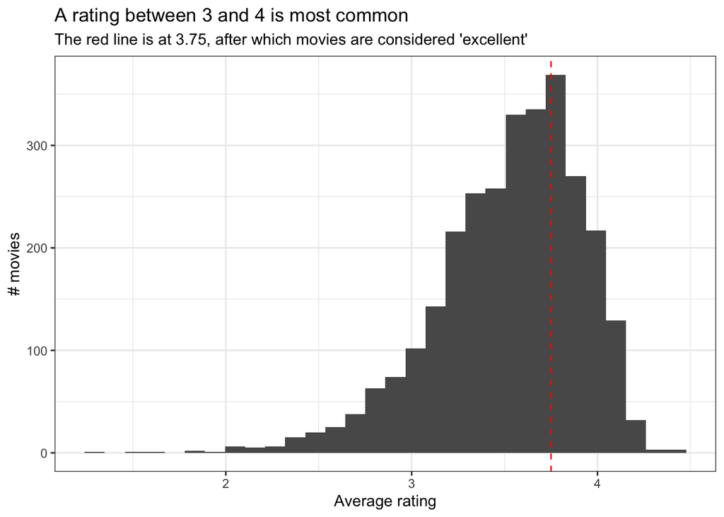

```r
ggplot(df, aes(x = av_rating)) +
  geom_histogram() +
  theme_bw() +
  labs(
    title = 'A rating between 3 and 4 is most common',
    subtitle = "The red line is at 3.75, after which movies are considered 'excellent'",
    x = 'Average rating',
    y = '# movies'
  ) +
  geom_vline(xintercept = 3.75, linetype="dashed", color = "red")
```

The good/bad variable is created below.

```r
# binarizing the data to make it a classification problem
svm_df <- df %>%
  mutate(y = if_else(av_rating > 3.75, 1, 0),
         y = as.factor(y)) %>%
  select(-av_rating, -title)

# splitting the data
set.seed(42)
splitting <- initial_split(svm_df, prop = 0.8)
train <- training(splitting)
test  <- testing(splitting)
```

Next, we train our model on the trainingset. We have picked a radial kernel, and tune our data on the sigma and cost parameters. We’re using a 10-fold crossvalidation.

We have used the Kappa as the metric to optimize. This is because we have a very imbalanced dataset. Most movied do not have a rating above 3.75. When datasets are very imbalanced, the accuracy is no longer the best way to assess the performance of the model. To optimize accuracy, the model could simply predict only negatives and still perform relatively well. That is definitely not desired behaviour however, since we would then have no idea what to watch. The kappa measure ensures that we take into account more.

```r
grid <- expand.grid(sigma = seq(0.03,0.05,0.002),
                    C = seq(1, 10, 1))
svm_tune <- train(
  y ~ .,
  data = train,
  method = "svmRadial",       # Radial kernel
  preProcess = c("center", "scale"),  # center & scale the data
  trControl = trainControl(method = "cv", number = 10), #cross-validation (10-fold)
  tuneGrid = grid,
  metric = 'Kappa'
)
```

To assess the performance of our model, we plot the outcomes for each of the combinations of tuning parameters.

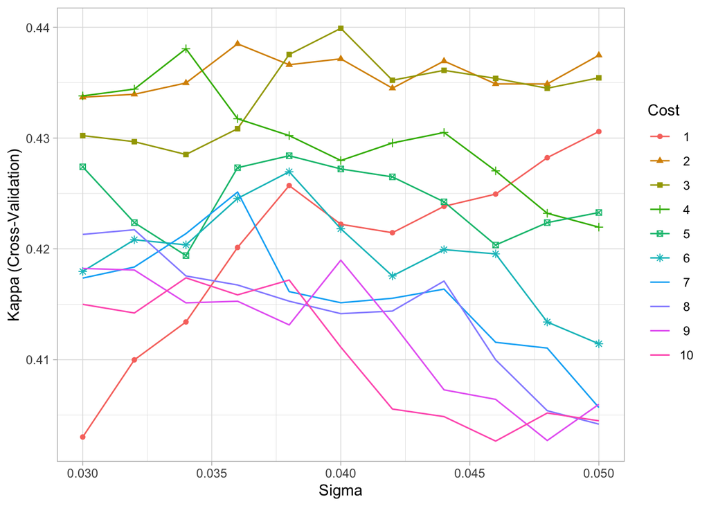

```r
ggplot(svm_tune) + theme_light()
```

```r
print(svm_tune)
```

```
## Support Vector Machines with Radial Basis Function Kernel
##
## 2334 samples
##   31 predictor
##    2 classes: '0', '1'
##
## Pre-processing: centered (31), scaled (31)
## Resampling: Cross-Validated (10 fold)
## Summary of sample sizes: 2100, 2100, 2101, 2102, 2100, 2100, ...
## Resampling results across tuning parameters:
##
##   sigma  C   Accuracy   Kappa
##   0.030   1  0.7707578  0.4030269
##   0.030   2  0.7793361  0.4336863
##   0.030   3  0.7759117  0.4302200
##   0.030   4  0.7754936  0.4338030
##   0.030   5  0.7724874  0.4274045
##   0.030   6  0.7682103  0.4179672
##   0.030   7  0.7673556  0.4173634
##   0.030   8  0.7682084  0.4213052
##   0.030   9  0.7669190  0.4182355
##   0.030  10  0.7647749  0.4149962
##   0.032   1  0.7728964  0.4099867
##   0.032   2  0.7789069  0.4339502
##   0.032   3  0.7750589  0.4296719
##   0.032   4  0.7750644  0.4344187
##   0.032   5  0.7699215  0.4223678
##   0.032   6  0.7686413  0.4208246
##   0.032   7  0.7673556  0.4183642
##   0.032   8  0.7682066  0.4217269
##   0.032   9  0.7656314  0.4180927
##   0.032  10  0.7639183  0.4142157
##   0.034   1  0.7737530  0.4134078
##   0.034   2  0.7789087  0.4349707
##   0.034   3  0.7741986  0.4285157
##   0.034   4  0.7759191  0.4380573
##   0.034   5  0.7686413  0.4193970
##   0.034   6  0.7686376  0.4203639
##   0.034   7  0.7682084  0.4213756
##   0.034   8  0.7656277  0.4175562
```

[output cut: 70 more lines]

```
##   0.048   9  0.7570697  0.4027090
##   0.048  10  0.7575008  0.4051879
##   0.050   1  0.7767609  0.4305874
##   0.050   2  0.7771956  0.4374743
##   0.050   3  0.7746315  0.4354348
##   0.050   4  0.7681992  0.4219621
##   0.050   5  0.7682047  0.4232796
##   0.050   6  0.7626326  0.4114376
##   0.050   7  0.7587810  0.4056841
##   0.050   8  0.7579263  0.4041868
##   0.050   9  0.7579318  0.4059750
##   0.050  10  0.7570734  0.4044889
##
## Kappa was used to select the optimal model using the largest value.
## The final values used for the model were sigma = 0.04 and C = 3.
```

```r
confusionMatrix(svm_tune)
```

```
## Cross-Validated (10 fold) Confusion Matrix
##
## (entries are percentual average cell counts across resamples)
##
##           Reference
## Prediction    0    1
##          0 62.0 15.8
##          1  6.5 15.7
##
##  Accuracy (average) : 0.7776
```

A higher Kappa represents a better model. Therefore, we need to choose a cost of 3 and a sigma of 0.04. This model has been chosen by the algorithm.

Next, we assess the performance of the model on the test dataset.

```r
#Model validation on the test set
test_validation = predict(svm_tune, test)
confusionMatrix(data = test_validation, as.factor(test$y))
```

```
## Confusion Matrix and Statistics
##
##           Reference
## Prediction   0   1
##          0 372  91
##          1  40  81
##
##                Accuracy : 0.7757
##                  95% CI : (0.7396, 0.8089)
##     No Information Rate : 0.7055
##     P-Value [Acc > NIR] : 8.253e-05
##
##                   Kappa : 0.4092
##
##  Mcnemar's Test P-Value : 1.251e-05
##
##             Sensitivity : 0.9029
##             Specificity : 0.4709
##          Pos Pred Value : 0.8035
##          Neg Pred Value : 0.6694
##              Prevalence : 0.7055
##          Detection Rate : 0.6370
##    Detection Prevalence : 0.7928
##       Balanced Accuracy : 0.6869
##
##        'Positive' Class : 0
##
```

To know how well our SVM performs relatively, we need to compare it to a simpler classification model. In this case, we compare it to a logistic regression, see below. We use the same tuning system and optimize it accordingly.

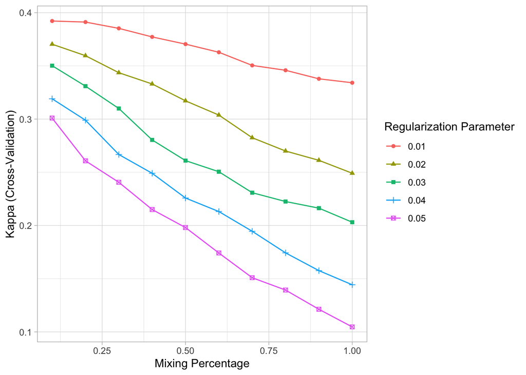

```r
grid <- expand.grid(alpha = seq(0.1, 1, 0.1), # x
                    lambda = seq(0.01,0.05,0.01)) # colored lines
log_tune <- train(
  y ~ .,
  data = train,
  method = "glmnet",         # Radial kernel
  preProcess = c("center", "scale"),  # center & scale the data
  trControl = trainControl(method = "cv", number = 10), #cross-validation (10-fold)
  tuneGrid = grid,
  metric = 'Kappa'
)

ggplot(log_tune) + theme_light()
```

```r
test_validation = predict(log_tune, test)
confusionMatrix(data = test_validation, as.factor(test$y))
```

```
## Confusion Matrix and Statistics
##
##           Reference
## Prediction   0   1
##          0 376 107
##          1  36  65
##
##                Accuracy : 0.7551
##                  95% CI : (0.7182, 0.7895)
##     No Information Rate : 0.7055
##     P-Value [Acc > NIR] : 0.004311
##
##                   Kappa : 0.3302
##
##  Mcnemar's Test P-Value : 4.808e-09
##
##             Sensitivity : 0.9126
##             Specificity : 0.3779
##          Pos Pred Value : 0.7785
##          Neg Pred Value : 0.6436
##              Prevalence : 0.7055
##          Detection Rate : 0.6438
##    Detection Prevalence : 0.8271
##       Balanced Accuracy : 0.6453
##
##        'Positive' Class : 0
##
```

Next, we set the threshold for a good movie at a rating of 4 instead of 3.75, using the same tuning parameters.

```r
# binarizing the data to make it a classification problem
svm_df <- df %>%
  mutate(y = if_else(av_rating > 4, 1, 0),
         y = as.factor(y)) %>%
  select(-av_rating, -title)

# splitting the data
set.seed(42)  # for reproducibility
splitting <- initial_split(svm_df, prop = 0.8)
train <- training(splitting)
test  <- testing(splitting)

grid <- expand.grid(sigma = seq(0.03,0.05,0.002),
                    C = seq(1, 10, 1))
svm_tune <- train(
  y ~ .,
  data = train,
  method = "svmRadial",       # Radial kernel
  preProcess = c("center", "scale"),  # center & scale the data
  trControl = trainControl(method = "cv", number = 10), #cross-validation (10-fold)
  tuneGrid = grid,
  metric = 'Kappa'
)

test_validation = predict(svm_tune, test)
confusionMatrix(data = test_validation, as.factor(test$y))
```

```
## Confusion Matrix and Statistics
##
##           Reference
## Prediction   0   1
##          0 537  39
##          1   4   4
##
##                Accuracy : 0.9264
##                  95% CI : (0.9021, 0.9462)
##     No Information Rate : 0.9264
##     P-Value [Acc > NIR] : 0.5405
##
##                   Kappa : 0.1369
##
##  Mcnemar's Test P-Value : 2.161e-07
##
##             Sensitivity : 0.99261
##             Specificity : 0.09302
##          Pos Pred Value : 0.93229
##          Neg Pred Value : 0.50000
##              Prevalence : 0.92637
##          Detection Rate : 0.91952
##    Detection Prevalence : 0.98630
##       Balanced Accuracy : 0.54281
##
##        'Positive' Class : 0
##
```

We see that our accuracy has increased massively but our specificity has dropped to only 9%. We see that the dataset is even more imbalanced when we take a boundary of 4. This means that we have so few instances of a good movie that the algorithm cannot identify them anymore. If the algorithm says it’s a good movie, there’s now a 50/50 chance that it actually is a good movie and most good movies are not recognized. This was a lot better for the model with a threshold of 3.75. Therefore, we we should use a more balanced dataset and take 3.75.

# Training an ANN model

Knowing whether a movie would be rated good or bad can be useful to decide if you want to watch it, but we need more detailed information to make any more complicated decisions such as whether to add it to your streaming service. To provide this information, we will be building an Artificial Neural Network. This network will predict the exact average rating that the movie will get.

First we create the test and training datasets.

```r
# removing the unnecessary title column
ann_df <- df %>%
  select( -title, -movieId, -`(no genres listed)` )

# splitting the data
set.seed(123)  # for reproducibility
splitting <- initial_split(ann_df, prop = 0.8)
train <- training(splitting)
test  <- testing(splitting)
```

We have already preprocessed the data above. However, we do need to center and scale it for the ANN to handle it properly. We save the mean and standard deviation to be able to denormalise the outcome later.

```r
# since we have previously preprocessed the data,
# we only need to center and scale it before we can use it
rec_obj <- recipe(av_rating ~ ., data = train) %>%
  step_center(all_predictors(), all_outcomes()) %>%
  step_scale(all_predictors(), all_outcomes()) %>%
  prep(data = train)

# in order to allow for denormalisations
center_history <- rec_obj$steps[[1]]$means["av_rating"] # Keeping the mean
scale_history  <- rec_obj$steps[[2]]$sds["av_rating"] #and the std
```

Next, we’re creating the X and Y sets.

```r
# Creating the X and Y sets
x_train_tbl <- bake(rec_obj, new_data = train) %>% select(-av_rating)
x_test_tbl  <- bake(rec_obj, new_data = test) %>% select(-av_rating)
#x_train_tbl <- train %>% select(-av_rating)
#x_test_tbl <- test %>% select(-av_rating)
glimpse(x_train_tbl)
```

```
## Rows: 2,334
## Columns: 29
## $ Adventure   <dbl> -0.4771554, -0.4771554, -0.4771554, -0.4771554, -0.4771554…
## $ Animation   <dbl> -0.2438009, -0.2438009, -0.2438009, -0.2438009, -0.2438009…
## $ Children    <dbl> -0.2457665, -0.2457665, -0.2457665, -0.2457665, -0.2457665…
## $ Comedy      <dbl> 1.4984034, -0.6670911, -0.6670911, -0.6670911, -0.6670911,…
## $ Fantasy     <dbl> -0.353222, 2.829868, -0.353222, -0.353222, -0.353222, -0.3…
## $ Action      <dbl> 1.703457, -0.586790, 1.703457, -0.586790, -0.586790, -0.58…
## $ Crime       <dbl> 2.4337784, -0.4107077, -0.4107077, -0.4107077, -0.4107077,…
## $ Thriller    <dbl> -0.6277709, -0.6277709, -0.6277709, 1.5922553, -0.6277709,…
## $ Romance     <dbl> -0.4560541, -0.4560541, -0.4560541, -0.4560541, -0.4560541…
## $ Drama       <dbl> -1.0462712, 0.9553657, -1.0462712, -1.0462712, -1.0462712,…
## $ Horror      <dbl> -0.3470557, -0.3470557, -0.3470557, 2.8801474, -0.3470557,…
## $ Mystery     <dbl> -0.3052351, -0.3052351, -0.3052351, -0.3052351, 3.2747590,…
## $ `Sci-Fi`    <dbl> -0.4415891, 2.2635786, 2.2635786, -0.4415891, -0.4415891, …
```

[output cut: 16 more lines]

```r
y_train_vec <- train$av_rating
y_test_vec  <- test$av_rating
```

The ANN we have chosen consists of three layers with 32 nodes each. We have set the dropout rate to 0.2 since intially we had a high level of overfitting where our trainingset had an R2 of 0.35 and the testset of 0.25. With a higher dropout rate the overfitting is less extreme. We have a mixture of linear and tan activation functions since our outcome needs to be continuous. The exact combination of nodes, activation functions and layers is based on trial and error.

```r
# NOTE FOR VIVIAN: TO RUN THIS YOU NEED TO RUN THE FOLLOWING IN THE CONSOLE FIRST:
# library(reticulate)
# conda_list() --> find the spyder2022 version of python
# use_python('path of spyder2022 version of python')
# use_condaenv('spyder2022')
# then and only then will keras run correctly. DO NOT FORGET

# Building our Artificial Neural Network
set.seed(123)
model_keras <- keras_model_sequential()

model_keras %>%

  # First hidden layer
  layer_dense(
    units              = 32,
    kernel_initializer = "uniform",
    activation         = "tanh",
    input_shape        = ncol(x_train_tbl)) %>%

  # Dropout to prevent overfitting
  layer_dropout(rate = 0.2) %>%

  # Second hidden layer
  layer_dense(
    units              = 32,
    kernel_initializer = "uniform",
    activation         = "relu") %>%

  # Dropout to prevent overfitting
  layer_dropout(rate = 0.2) %>%

    # Third hidden layer
  layer_dense(
    units              = 32,
    kernel_initializer = "uniform",
    activation         = "tanh") %>%

  # Dropout to prevent overfitting
  layer_dropout(rate = 0.2) %>%

  # Output layer
  layer_dense(
    units              = 1, # we only need 1 output
    kernel_initializer = "uniform",
    activation         = "linear") %>%  # we take a linear activation for our continuous output

  # Compile NN
  compile(
    optimizer = 'adam',
    loss='mse',
    metrics= list('mean_squared_error')
  )

#display model architecture
model_keras
```

```
## Model: "sequential"
## ________________________________________________________________________________
##  Layer (type)                       Output Shape                    Param #
## ================================================================================
##  dense_3 (Dense)                    (None, 32)                      960
##  dropout_2 (Dropout)                (None, 32)                      0
##  dense_2 (Dense)                    (None, 32)                      1056
##  dropout_1 (Dropout)                (None, 32)                      0
##  dense_1 (Dense)                    (None, 32)                      1056
##  dropout (Dropout)                  (None, 32)                      0
##  dense (Dense)                      (None, 1)                       33
## ================================================================================
## Total params: 3,105
## Trainable params: 3,105
## Non-trainable params: 0
## ________________________________________________________________________________
```

```r
# Train model
history <- fit(
  object           = model_keras,
  x                = as.matrix(x_train_tbl),
  y                = y_train_vec,
  batch_size       = 50,
  epochs           = 50,
  validation_split = 0.30 #to include 30% of the data for model validation, which prevents overfitting.
 # verbose          = 0
)
```

```r
# Print a summary of the training history
print(history)
```

```
##
## Final epoch (plot to see history):
##                   loss: 0.1992
##     mean_squared_error: 0.1992
##               val_loss: 0.09815
## val_mean_squared_error: 0.09815
```

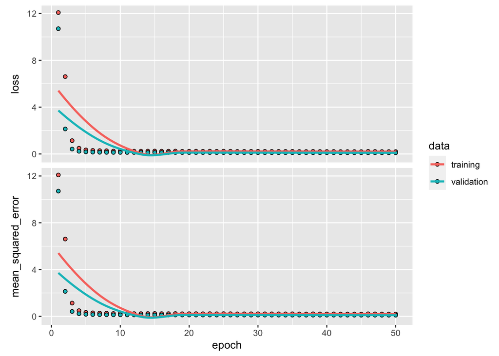

```r
# Plot the training/validation history of our Keras model
plot(history)
```

Next, we’re evaluating the model:

```r
scores = model_keras %>% evaluate(as.matrix(x_test_tbl), y_test_vec, verbose = 0)
print(scores)
```

```
##               loss mean_squared_error
##          0.1025882          0.1025882
```

```r
print("training data")
```

```
## [1] "training data"
```

```r
y_train_pred = model_keras %>%
  predict(as.matrix(x_train_tbl)) %>%
  as.vector()
# de-normalize to original scale
y_train_pred <- (y_train_pred * scale_history + center_history) #denormalization
y_train_vec <- (y_train_vec * scale_history + center_history) #denormalization

R2 = R2(y_train_vec, y_train_pred)
R2
```

```
## [1] 0.3713745
```

```r
print("testing data")
```

```
## [1] "testing data"
```

```r
y_test_pred = model_keras %>%
  predict(as.matrix(x_test_tbl)) %>%
  as.vector()
y_test_vec <- (y_test_vec * scale_history + center_history)
y_test_pred <- (y_test_pred * scale_history + center_history)
R2 = R2(y_test_vec,y_test_pred)
R2
```

```
## [1] 0.3768236
```

To see how badly or well our model is performing, we compare it against a simple linear regression.

```r
lm_data <- bake(rec_obj, new_data = train)
lm_data_test <- bake(rec_obj, new_data = test)

control <- trainControl (
    method="cv",
    number=10,
    verboseIter=FALSE)

linear_model <- train(
    av_rating ~.,
    data = lm_data,
    method = "lm",
    trControl = control
   )
predicted <- predict(linear_model, lm_data_test)

summary(linear_model)
```

```
##
## Call:
## lm(formula = .outcome ~ ., data = dat)
##
## Residuals:
##     Min      1Q  Median      3Q     Max
## -4.9336 -0.4331  0.0813  0.5693  2.0480
##
## Coefficients:
##                     Estimate Std. Error t value Pr(>|t|)
## (Intercept)       -6.353e-15  1.744e-02   0.000 1.000000
## Adventure         -1.374e-02  2.120e-02  -0.648 0.517057
## Animation          1.341e-01  2.140e-02   6.265 4.43e-10 ***
## Children          -6.230e-02  2.228e-02  -2.795 0.005225 **
## Comedy            -1.377e-01  2.145e-02  -6.417 1.68e-10 ***
## Fantasy           -9.915e-02  1.987e-02  -4.989 6.51e-07 ***
## Action            -1.292e-01  2.196e-02  -5.883 4.62e-09 ***
## Crime              4.592e-02  1.952e-02   2.353 0.018721 *
## Thriller          -8.853e-02  2.100e-02  -4.217 2.57e-05 ***
## Romance           -2.441e-02  1.898e-02  -1.286 0.198468
## Drama              1.479e-01  2.221e-02   6.660 3.41e-11 ***
## Horror            -1.207e-01  1.974e-02  -6.116 1.12e-09 ***
## Mystery            3.755e-02  1.899e-02   1.978 0.048100 *
## `\\`Sci-Fi\\``    -1.178e-01  2.110e-02  -5.582 2.66e-08 ***
## Musical            1.792e-02  1.840e-02   0.974 0.330221
## War                4.775e-02  1.855e-02   2.574 0.010120 *
## IMAX              -6.173e-02  1.866e-02  -3.309 0.000950 ***
## Western            3.706e-02  1.765e-02   2.100 0.035811 *
## `\\`Film-Noir\\``  7.752e-02  1.797e-02   4.314 1.67e-05 ***
## Documentary        5.645e-02  1.826e-02   3.091 0.002020 **
## PC1                2.709e-01  1.820e-02  14.885  < 2e-16 ***
## PC2                1.896e-02  1.819e-02   1.043 0.297261
## PC3               -9.875e-02  1.829e-02  -5.399 7.41e-08 ***
## PC4                1.098e-01  1.828e-02   6.007 2.18e-09 ***
## PC5               -7.031e-02  1.894e-02  -3.712 0.000211 ***
## PC6                1.855e-02  1.856e-02   1.000 0.317620
## PC7               -2.997e-02  1.787e-02  -1.677 0.093588 .
## PC8                6.809e-02  1.826e-02   3.729 0.000197 ***
## PC9                4.835e-04  1.804e-02   0.027 0.978613
## PC10               3.176e-02  1.839e-02   1.727 0.084302 .
## ---
## Signif. codes:  0 '***' 0.001 '**' 0.01 '*' 0.05 '.' 0.1 ' ' 1
##
## Residual standard error: 0.8425 on 2304 degrees of freedom
## Multiple R-squared:  0.299,  Adjusted R-squared:  0.2902
## F-statistic: 33.89 on 29 and 2304 DF,  p-value: < 2.2e-16
```

```r
mse <- mean((lm_data_test$av_rating - predicted)^2)
rmse <- sqrt(mse)
mse
```

```
## [1] 0.6913777
```